# Fall 2021 - Math 421 - Midterm

## III. Predictive Models

Continue with the data from part I. Use the follows as the target and input variables:

*Target Variable*: Create the target variable taking value of

- `low` if the total charge of a patient (`tot`) is smaller than the median of the total charge, and
- `high` otherwise.

```r
median_tot<-median(df$tot)

df$target<- ifelse(df$tot<=21854,"low","high")
```

*Input Variables*:

- “age”,“sex”,“raceethn”,“provider”,“moa”,“mod”,“admtype”,“campus”, ‘los’

```r
d <- df[,c("age","sex","raceethn","provider","moa","mod","admtype","campus", 'los','target')]
d <- d %>% filter(sex!=9)
```

1. Use `filter` function to filter out rows where `raceethn==''` or `admtype==''`. Make sure all the categorical variables are factor, numeric variables are numeric. Set Training : Testing Split = 10 : 90

```r
library(tidyverse)
d <- d %>% filter(raceethn!=' ') %>% filter(admtype!=' ')
d$raceethn <- factor(d$raceethn)
d$provider <- factor(d$provider)
d$admtype <- factor(d$admtype)
d$campus <- factor(d$campus)
d$sex <- factor(d$sex)
library(caret)
splitIndex <- createDataPartition(d$target, p = .05,                           list = FALSE)
train <- d[ splitIndex,]
test <- d[-splitIndex,]
```

2. Train a decision tree using `rpart`. Plot the decision tree. Plot the variable importance ranked by the tree.

[figure not shown]

```r
#install.packages('rpart')
#install.packages('rattle')
library(rpart)
tree_model <- rpart(target ~ ., data = train,
                 control = rpart.control(maxdepth = 3))
library(rattle)
fancyRpartPlot(tree_model)
```

```r
tree_model$variable.importance
```

```
##        los    admtype   provider        age     campus   raceethn
## 878.652291 313.129782 179.251799  93.881021  46.009047   9.085693
```

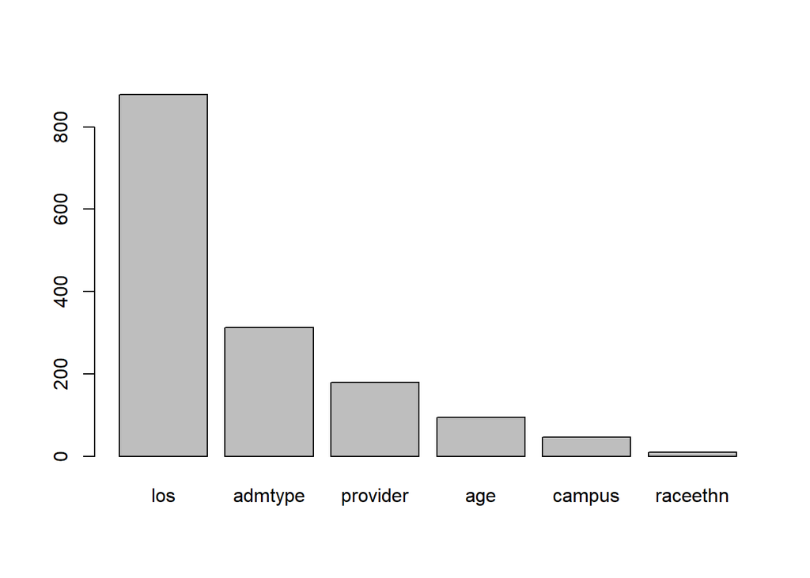

```r
barplot(tree_model$variable.importance)
```

```r
trControl = trainControl(method = "cv",
                         number = 5)

forest_ranger <- train(target~., data=train,
                    method = "ranger",
                    trControl = trControl,
                    na.action=na.omit)

tree_approach <- train(target~., data=train,
                                method = "rpart2",
                                trControl = trControl,
                       na.action=na.omit)
glm <- train(target~., data=train,
                                method = "glm",
                                trControl = trControl,  na.action=na.omit)
```

4. Plot the comparison of the models in 3.

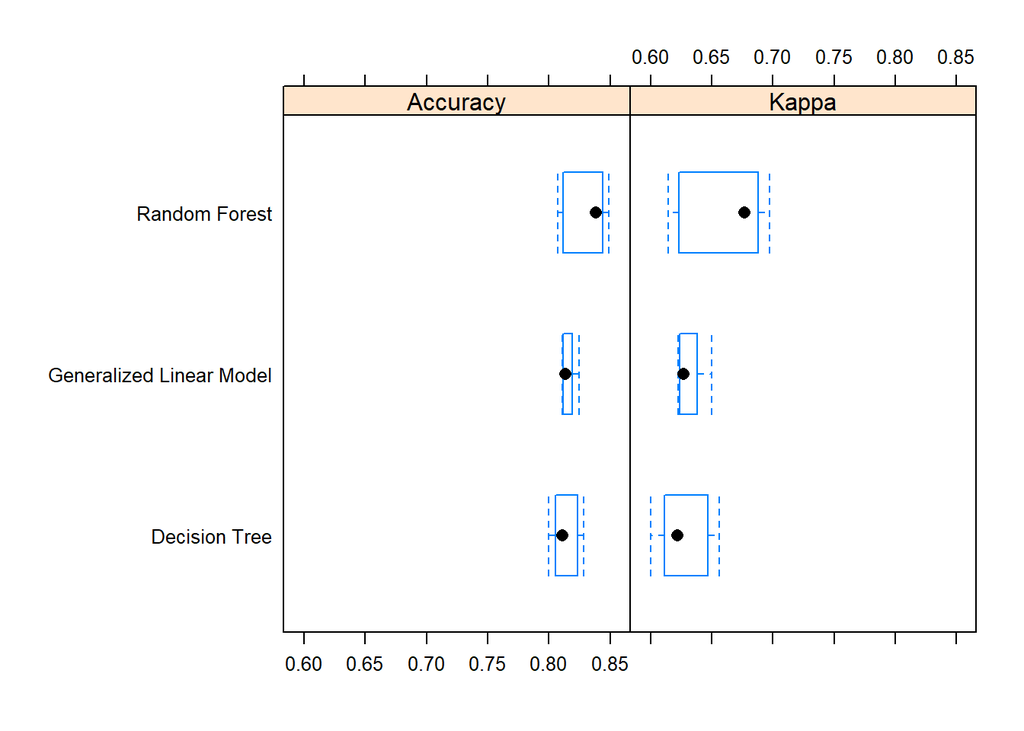

```r
results <- resamples(list('Random Forest' = forest_ranger,
                          'Decision Tree' = tree_approach,
                          'Generalized Linear Model'= glm))
bwplot(results)
```

5. What is your final selection for the model? Test the accuracy of your final model on the test data.

```r
pred <- predict(forest_ranger, test)
table(pred)
```

```
## pred
##  high   low
## 59745 61401
```

```r
cm <- confusionMatrix(data = pred, reference = as.factor(test$target), positive = "high")
cm$overall[1]
```

```
##  Accuracy
## 0.8237333
```

```r
##The selection for the best model is Random Forest. This yielded an accuracy of .823.
```

6. Create another `target` variable (binary), decide the input variables and redo 1 to 5.

```r
library(caret)
library(tidyverse)
df$Targ<- ifelse(df$los < 5,"short","long")
df$Targ <- factor(df$Targ)
ds <- df[,c("age","sex","raceethn","provider","moa","mod","admtype","campus", 'tot','Targ')]
ds <- ds %>% filter(sex!=9) %>% filter(raceethn!=' ') %>% filter(admtype!=' ')
```

```r
ds$provider <- factor(ds$provider)
ds$admtype <- factor(ds$admtype)
ds$campus <- factor(ds$campus)
ds$sex <- factor(ds$sex)

splitIndex1 <- createDataPartition(ds$Targ, p =.05,                           list = FALSE)
train1 <- ds[ splitIndex1,]
test1 <- ds[-splitIndex1,]
trControl1 = trainControl(method = "cv",
                         number = 5)
```

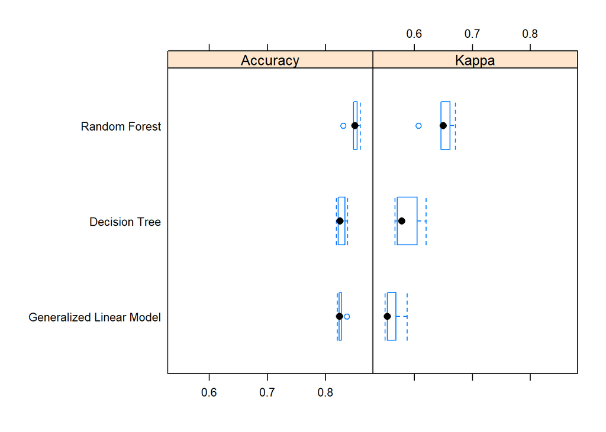

```r
library(caret)
forest_ranger1 <- train(Targ~., data=train1,
                    method = "ranger",
                    trControl = trControl,
                    na.action=na.omit)

tree_approach1 <- train(Targ~., data=train1,
                                method = "rpart2",
                                trControl = trControl,
                       na.action=na.omit)
glm1 <- train(Targ~., data=train1,
                                method = "glm",
                                trControl = trControl,  na.action=na.omit)

results1 <- resamples(list('Random Forest' = forest_ranger1,
                          'Decision Tree' = tree_approach1,
                          'Generalized Linear Model'= glm1))
bwplot(results1)
```

```r
pred1 <- predict(forest_ranger1, test1)
table(pred1)
```

```
## pred1
##  long short
## 37227 83919
```

```r
length(pred1)
```

```
## [1] 121146
```

```r
cm1 <- confusionMatrix(data = pred1, reference = test1$Targ, positive = "short")


cm1$overall[1]
```

```
##  Accuracy
## 0.8397801
```

```r
##Accuracy is .84 for random forest.
```

7. Write a paragraph to summarize the section and give your comments on the results.

## This section was used to make a statistical model to predict a certain variable. For the first part, we wanted to predict total cost and the second example was length of stay. These were interesting tests because they both showed that random forest was the best model for predicting. Using different types of models we were able to choose the most accurate predictor for each of the variables.